# Assignment 3

##Data Description This data was downloaded from Kaggle.com, a site that houses open source datasets. This specific dataset is titled: “New York City Airbnb Open Data,” and was originally sourced from Airbnb. From the Kaggle website (below):

##Context Since 2008, guests and hosts have used Airbnb to expand on traveling possibilities and present more unique, personalized way of experiencing the world. This dataset describes the listing activity and metrics in NYC, NY for 2019.

##Content This data file includes all needed information to find out more about hosts, geographical availability, necessary metrics to make predictions and draw conclusions.

https://www.kaggle.com/dgomonov/new-york-city-airbnb-open-data/downloads/new-york-city-airbnb-open-data.zip/3

[output not shown]

##Task 3. Exploring the Price variable (a) Plot a histogram of price.

```r
#This is where code goes
```

[output not shown]

[output not shown]

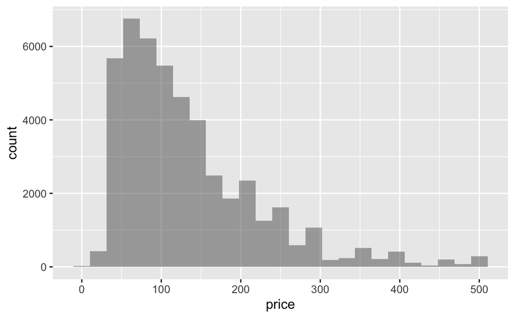

```r
gf_histogram(~price , data = filter_data)
```

```r
#This is where code goes
```

[output not shown]